# Tugas 1 Individu

Delia Fitri Audina_G1401221013

# Pemulusan MPDW

## a. Library / Packages

```r
library("forecast")
```

```r
library("graphics")
library("TTR")
library("TSA")
library("ggplot2")
```

## b. Impor Data

```r
library(readxl)

data1 <- read_excel("C:/Users/Delia/OneDrive/Documents/Data MPDW 301-400.xlsx")
data1
```

```
## # A tibble: 100 × 2
##    Periode             Kendaraan
##    <dttm>                  <dbl>
##  1 2024-02-07 00:00:00     38390
##  2 2024-02-08 00:00:00     58790
##  3 2024-02-09 00:00:00     31121
##  4 2024-02-10 00:00:00     29444
##  5 2024-02-11 00:00:00     24777
##  6 2024-02-12 00:00:00     24370
##  7 2024-02-13 00:00:00     27939
##  8 2024-02-14 00:00:00     19336
##  9 2024-02-15 00:00:00     23742
## 10 2024-02-16 00:00:00     29353
## # ℹ 90 more rows
```

## c. Eksplorasi Data

```r
View(data1)
str(data1)
```

```
## tibble [100 × 2] (S3: tbl_df/tbl/data.frame)
##  $ Periode  : POSIXct[1:100], format: "2024-02-07" "2024-02-08" ...
##  $ Kendaraan: num [1:100] 38390 58790 31121 29444 24777 ...
```

```r
dim(data1)
```

```
## [1] 100   2
```

```r
# Mengubah data agar terbaca sebagai data deret waktu dengan fungsi `ts()`
data1.ts <- ts(data1$Kendaraan)
```

```r
# Menampilkan ringkasan data
summary(data1.ts)
```

```
##    Min. 1st Qu.  Median    Mean 3rd Qu.    Max.
##   16229   24660   27634   32560   32671  122607
```

## d. Membuat plot data deret waktu

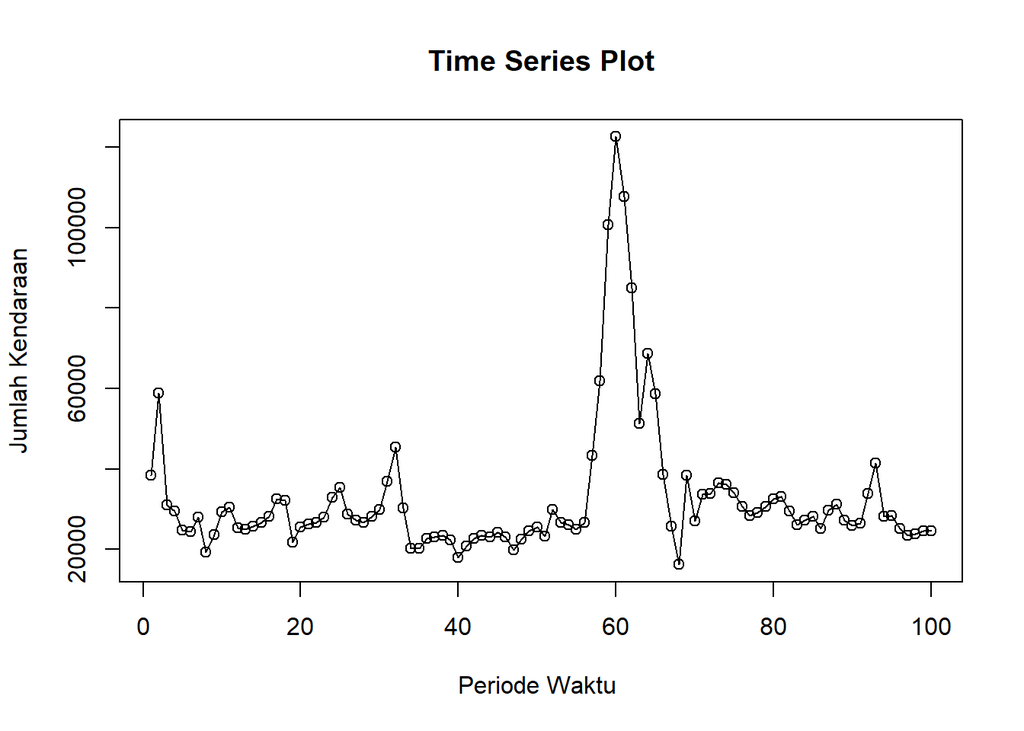

```r
ts.plot(data1.ts, xlab="Periode Waktu ", ylab="Jumlah Kendaraan",
        main = "Time Series Plot")
points(data1.ts)
```

# Jenis Pemulusan

## Single Moving Average & Double Moving Average

#### a.Pembagian Data

```r
#membagi data latih 80% dan data uji 20%
training_ma <- data1[1:80,]
testing_ma <- data1[81:100,]
train_ma.ts <- ts(training_ma$Kendaraan)
test_ma.ts <- ts(testing_ma$Kendaraan)
```

#### b.Eksplorasi Data

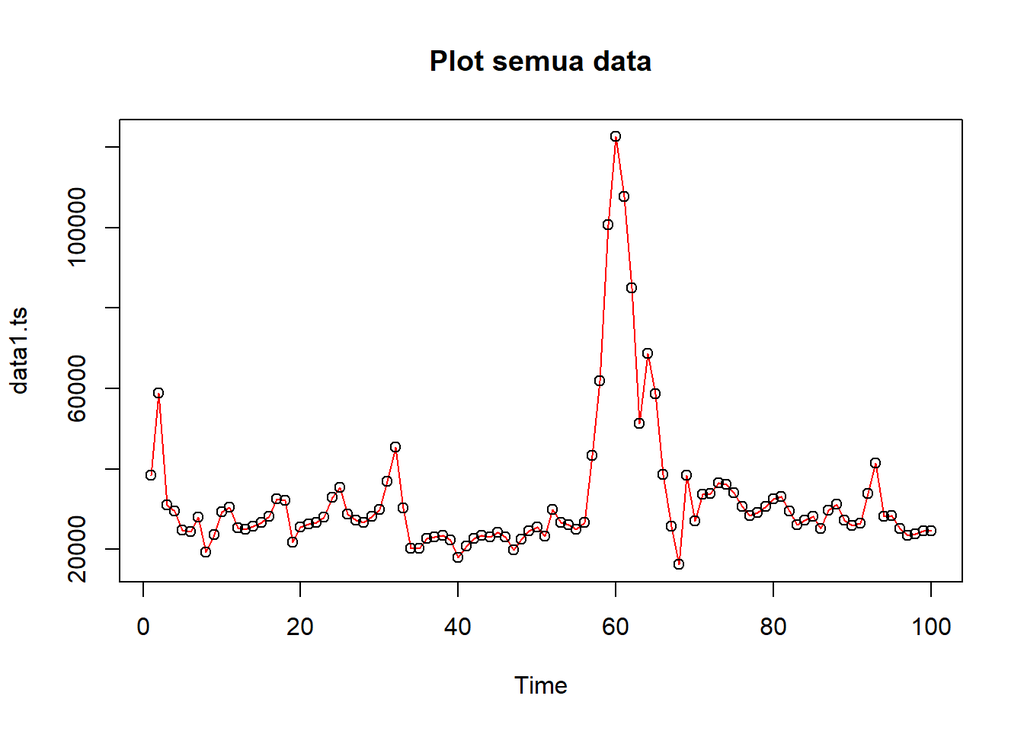

```r
#eksplorasi keseluruhan data
plot(data1.ts, col="red",main="Plot semua data",type ="o")
points(data1.ts)
```

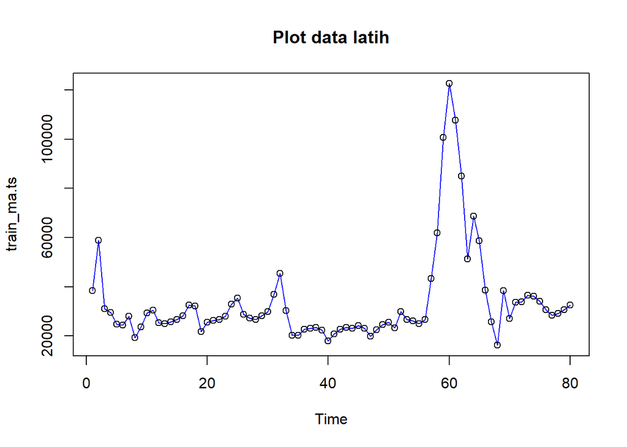

```r
#eksplorasi data latih
plot(train_ma.ts, col="blue",main="Plot data latih", type="o")
points(train_ma.ts)
```

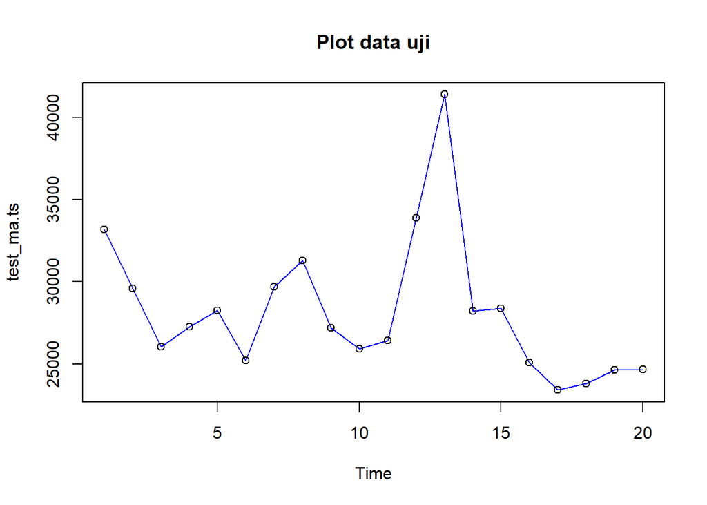

```r
#eksplorasi data uji
plot(test_ma.ts, col="blue",main="Plot data uji",type="o")
points(test_ma.ts)
```

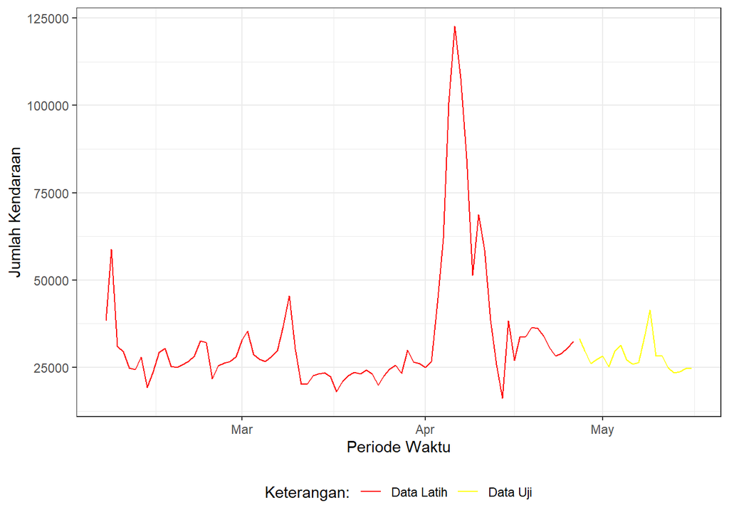

```r
#Eksplorasi dengan GGPLOT
library(ggplot2)
ggplot() +
  geom_line(data = training_ma, aes(x = Periode, y = Kendaraan, col = "Data Latih")) +
  geom_line(data = testing_ma, aes(x = Periode, y = Kendaraan, col = "Data Uji")) +
  labs(x = "Periode Waktu", y = "Jumlah Kendaraan", color = "Legend") +
  scale_colour_manual(name="Keterangan:", breaks = c("Data Latih", "Data Uji"),
                      values = c("red", "yellow")) +
  theme_bw() + theme(legend.position = "bottom",
                     plot.caption = element_text(hjust=0.5, size=12))
```

### 1. Single Moving Average (SMA)

- Data suatu periode dipengaruhi oleh data periode sebelumnya.
- Cocok digunakan untuk pola data stasioner atau konstan.
- Prinsip dasar : rata rata dari m buah data pada periode (ke-t) hingga periode ke (t-m+1).
- Pemulusan menggunakan metode SMA dilakukan dengan fungsi `SMA()`. Dalam hal ini akan dilakukan pemulusan dengan parameter `m=4`.

```r
library(TTR)
data.sma<-SMA(train_ma.ts, n=4)
data.sma
```

```
## Time Series:
## Start = 1
## End = 80
## Frequency = 1
##  [1]        NA        NA        NA  39436.25  36033.00  27428.00  26632.50
##  [8]  24105.50  23846.75  25092.50  25719.50  27206.00  27530.50  26644.25
## [15]  25697.50  26439.75  28325.00  29914.50  28673.50  27991.50  26400.50
## [22]  25041.25  26631.25  28485.25  30760.25  31266.75  31084.75  29522.50
## [29]  27732.50  27996.00  30407.25  35104.25  35651.25  33240.75  29054.25
## [36]  23366.25  21558.00  22367.75  22907.00  21729.25  21175.00  20978.00
## [43]  21268.75  22532.00  23369.25  23501.75  22592.75  22441.25  22524.75
## [50]  23131.25  23994.00  25866.75  26379.50  26513.75  26937.25  26124.75
## [57]  30307.00  39245.00  58183.75  82159.75  98249.50 104012.00  91633.75
## [64]  78169.50  65908.50  54313.50  47944.75  34814.50  29729.25  26864.75
## [71]  28813.00  33205.75  32732.50  35019.00  35117.00  34329.25  32294.00
## [78]  30502.50  29642.00  30101.25
```

```r
#forecast 1 periode ke depan
data.ramal<-c(NA,data.sma)
data.ramal
```

```
##  [1]        NA        NA        NA        NA  39436.25  36033.00  27428.00
##  [8]  26632.50  24105.50  23846.75  25092.50  25719.50  27206.00  27530.50
## [15]  26644.25  25697.50  26439.75  28325.00  29914.50  28673.50  27991.50
## [22]  26400.50  25041.25  26631.25  28485.25  30760.25  31266.75  31084.75
## [29]  29522.50  27732.50  27996.00  30407.25  35104.25  35651.25  33240.75
## [36]  29054.25  23366.25  21558.00  22367.75  22907.00  21729.25  21175.00
## [43]  20978.00  21268.75  22532.00  23369.25  23501.75  22592.75  22441.25
## [50]  22524.75  23131.25  23994.00  25866.75  26379.50  26513.75  26937.25
## [57]  26124.75  30307.00  39245.00  58183.75  82159.75  98249.50 104012.00
## [64]  91633.75  78169.50  65908.50  54313.50  47944.75  34814.50  29729.25
## [71]  26864.75  28813.00  33205.75  32732.50  35019.00  35117.00  34329.25
## [78]  32294.00  30502.50  29642.00  30101.25
```

```r
#forecast 20 periode ke depan
data.gab<-cbind(aktual=c(train_ma.ts,rep(NA,20)),pemulusan=c(data.sma,rep(NA,20)),ramalan=c(data.ramal,rep(data.ramal[length(data.ramal)],19)))
data.gab
```

```
##        aktual pemulusan   ramalan
##   [1,]  38390        NA        NA
##   [2,]  58790        NA        NA
##   [3,]  31121        NA        NA
##   [4,]  29444  39436.25        NA
##   [5,]  24777  36033.00  39436.25
##   [6,]  24370  27428.00  36033.00
##   [7,]  27939  26632.50  27428.00
##   [8,]  19336  24105.50  26632.50
##   [9,]  23742  23846.75  24105.50
##  [10,]  29353  25092.50  23846.75
##  [11,]  30447  25719.50  25092.50
##  [12,]  25282  27206.00  25719.50
##  [13,]  25040  27530.50  27206.00
##  [14,]  25808  26644.25  27530.50
```

[output cut: 86 more lines]

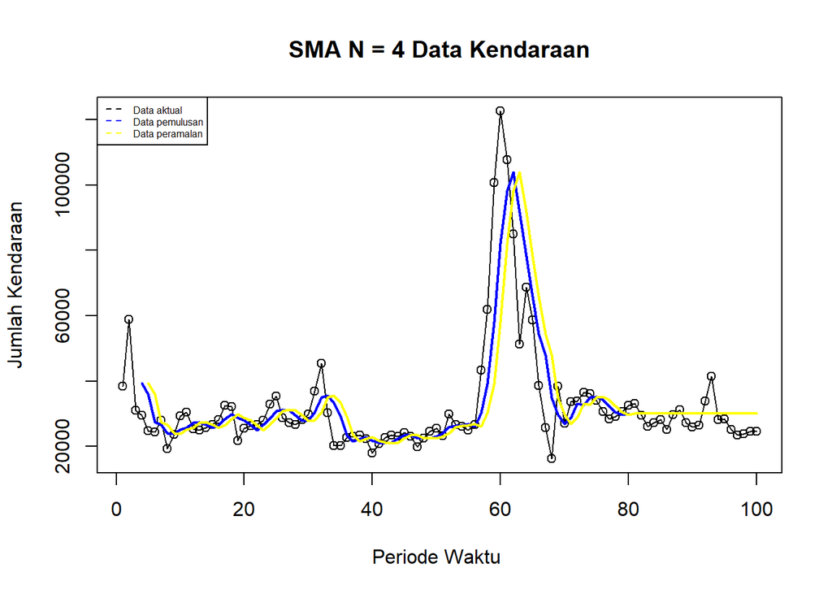

```r
# plot data deret waktu dari hasil peramalan
ts.plot(data1.ts, xlab="Periode Waktu ", ylab="Jumlah Kendaraan", main= "SMA N = 4 Data Kendaraan")
points(data1.ts)
lines(data.gab[,2],col="blue",lwd=2)
lines(data.gab[,3],col="yellow",lwd=2)
legend("topleft",c("Data aktual","Data pemulusan","Data peramalan"), lty=8, col=c("black","blue","yellow"), cex=0.5)
```

Selanjutnya perhitungan akurasi :

- *Sum Squares Error* (SSE)
- *Mean Square Error* (MSE)
- *Mean Absolute Percentage Error* (MAPE)

```r
#Menghitung nilai keakuratan data latih
error_train.sma = train_ma.ts-data.ramal[1:length(train_ma.ts)]
SSE_train.sma = sum(error_train.sma[5:length(train_ma.ts)]^2)
MSE_train.sma = mean(error_train.sma[5:length(train_ma.ts)]^2)
MAPE_train.sma = mean(abs((error_train.sma[5:length(train_ma.ts)]/train_ma.ts[5:length(train_ma.ts)])*100))

akurasi_train.sma <- matrix(c(SSE_train.sma, MSE_train.sma, MAPE_train.sma))
row.names(akurasi_train.sma)<- c("SSE", "MSE", "MAPE")
colnames(akurasi_train.sma) <- c("Akurasi m = 4")
akurasi_train.sma
```

```
##      Akurasi m = 4
## SSE   1.814191e+10
## MSE   2.387094e+08
## MAPE  2.244475e+01
```

Dalam hal ini nilai MAPE data latih pada metode pemulusan SMA sebesar 22,44%, nilai ini tidak dapat dikategorikan sebagai nilai akurasi yang sangat baik pada data lati dan perlu dilakukan evaluasi lebih lanjut pada data uji untuk melihat performa keseluruhan dari model tersebut. Selanjutnya dilakukan perhitungan nilai MAPE data uji pada metde pemulusan SMA.

```r
#Menghitung nilai keakuratan data uji
error_test.sma = test_ma.ts-data.gab[81:100,3]
SSE_test.sma = sum(error_test.sma^2)
MSE_test.sma = mean(error_test.sma^2)
MAPE_test.sma = mean(abs((error_test.sma/test_ma.ts*100)))

akurasi_test.sma <- matrix(c(SSE_test.sma, MSE_test.sma, MAPE_test.sma))
row.names(akurasi_test.sma)<- c("SSE", "MSE", "MAPE")
colnames(akurasi_test.sma) <- c("Akurasi m = 4")
akurasi_test.sma
```

```
##      Akurasi m = 4
## SSE   4.201603e+08
## MSE   2.100801e+07
## MAPE  1.396950e+01
```

Perhitungan akurasi menggunakan data uji menghasilkan nilai MAPE 13.9695% sehingga nilai akurasi ini dapat dikategorikan sebagai akurasi yang baik. Namun, nilai ini tidak dapat dikategorikan sebagai nilai akurasi yang sangat baik karena melebihi batas 10% untuk kategori sangat baik.

Hasil ini menunjukkan bahwa **metode pemulusan SMA** yang digunakan memberikan hasil peramalan yang cukup baik, tetapi tidak optimal atau sangat baik dan **kurang cocok digunakan**.

### 2. Double Moving Average (DMA)

- Pada dasarnya mirip dengan SMA.
- Metode ini lebih cocok digunakan untuk pola data trend.
- Proses pemulusan dengan rata rata dalam metode ini dilakukan sebanyak 2 kali.

```r
dma <- SMA(data.sma, n = 4)
At <- 2*data.sma - dma
Bt <- 2/(4-1)*(data.sma - dma)
data.dma<- At+Bt
data.ramal2<- c(NA, data.dma)

t = 1:20
f = c()

for (i in t) {
  f[i] = At[length(At)] + Bt[length(Bt)]*(i)
}

data.gab2 <- cbind(aktual = c(train_ma.ts,rep(NA,20)), pemulusan1 = c(data.sma,rep(NA,20)),pemulusan2 = c(data.dma, rep(NA,20)),At = c(At, rep(NA,20)), Bt = c(Bt,rep(NA,20)),ramalan = c(data.ramal2, f[-1]))
data.gab2
```

```
##        aktual pemulusan1 pemulusan2        At           Bt    ramalan
##   [1,]  38390         NA         NA        NA           NA         NA
##   [2,]  58790         NA         NA        NA           NA         NA
##   [3,]  31121         NA         NA        NA           NA         NA
##   [4,]  29444   39436.25         NA        NA           NA         NA
##   [5,]  24777   36033.00         NA        NA           NA         NA
##   [6,]  24370   27428.00         NA        NA           NA         NA
##   [7,]  27939   26632.50  17049.271  20882.56  -3833.29167         NA
##   [8,]  19336   24105.50  16698.417  19661.25  -2962.83333  17049.271
##   [9,]  23742   23846.75  21086.021  22190.31  -1104.29167  16698.417
##  [10,]  29353   25092.50  25381.146  25265.69    115.45833  21086.021
##  [11,]  30447   25719.50  27433.562  26747.94    685.62500  25381.146
##  [12,]  25282   27206.00  30105.688  28945.81   1159.87500  27433.562
##  [13,]  25040   27530.50  29436.125  28673.88    762.25000  30105.688
##  [14,]  25808   26644.25  26426.229  26513.44    -87.20833  29436.125
```

[output cut: 86 more lines]

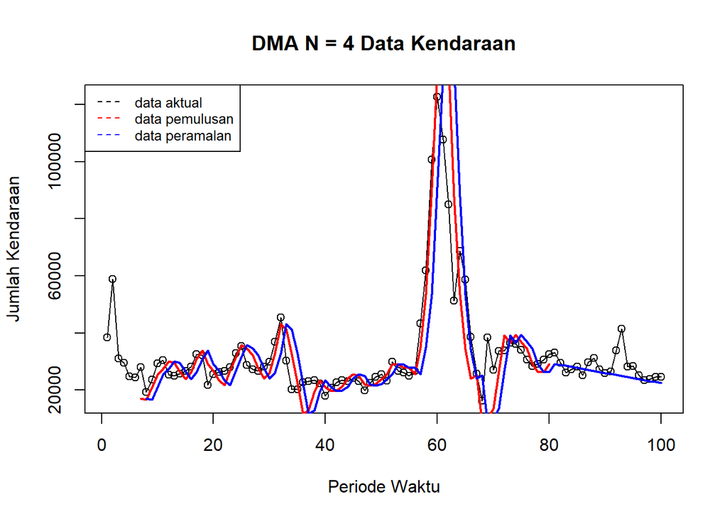

```r
# plot hasil pemulusan menggunakan metode DMA
ts.plot(data1.ts, xlab="Periode Waktu", ylab="Jumlah Kendaraan", main= "DMA N = 4 Data Kendaraan")
points(data1.ts)
lines(data.gab2[,3],col="red",lwd=2)
lines(data.gab2[,6],col="blue",lwd=2)
legend("topleft",c("data aktual","data pemulusan","data peramalan"), lty=8, col=c("black","red","blue"), cex=0.8)
```

Perhitungan akurasi dilakukan dengan ukuran akurasi SSE, MSE dan MAPE.

```r
#Menghitung nilai keakuratan data latih
error_train.dma = train_ma.ts-data.ramal2[1:length(train_ma.ts)]
SSE_train.dma = sum(error_train.dma[8:length(train_ma.ts)]^2)
MSE_train.dma = mean(error_train.dma[8:length(train_ma.ts)]^2)
MAPE_train.dma = mean(abs((error_train.dma[8:length(train_ma.ts)]/train_ma.ts[8:length(train_ma.ts)])*100))

akurasi_train.dma <- matrix(c(SSE_train.dma, MSE_train.dma, MAPE_train.dma))
row.names(akurasi_train.dma)<- c("SSE", "MSE", "MAPE")
colnames(akurasi_train.dma) <- c("Akurasi m = 4")
akurasi_train.dma
```

```
##      Akurasi m = 4
## SSE   1.997204e+10
## MSE   2.735895e+08
## MAPE  2.471958e+01
```

Perhitungan akurasi pada data latih menggunakan nilai MAPE menghasilkan nilai MAPE yang lebih dari 10% sehingga dikategorikan cukup baik. Selanjutnya, perhitungan nilai akurasi dilakukan pada data uji.

```r
#Menghitung nilai keakuratan data uji
error_test.dma = test_ma.ts-data.gab2[81:100,6]
SSE_test.dma = sum(error_test.dma^2)
MSE_test.dma = mean(error_test.dma^2)
MAPE_test.dma = mean(abs((error_test.dma/test_ma.ts*100)))

akurasi_test.dma <- matrix(c(SSE_test.dma, MSE_test.dma, MAPE_test.dma))
row.names(akurasi_test.dma)<- c("SSE", "MSE", "MAPE")
colnames(akurasi_test.dma) <- c("Akurasi m = 4")
akurasi_test.dma
```

```
##      Akurasi m = 4
## SSE   4.421128e+08
## MSE   2.210564e+07
## MAPE  9.219580e+00
```

Perhitungan akurasi menggunakan data uji menghasilkan nilai MAPE yang kurang dari 10% sehingga nilai akurasi ini dapat dikategorikan sebagai sangat baik.

Pada data latih, metode SMA lebih baik dibandingkan dengan metode DMA, sedangkan pada data uji, metode DMA lebih baik dibandingkan SMA.

## Single Exponential Smoothing & Double Exponential Smoothing

#### a. Pembagian Data

```r
#membagi training dan testing (80% data latih dan 20% data uji)
training<-data1[1:80,]
testing<-data1[81:100,]
train.ts <- ts(training$Kendaraan)
test.ts <- ts(testing$Kendaraan)
```

#### b. Eksplorasi

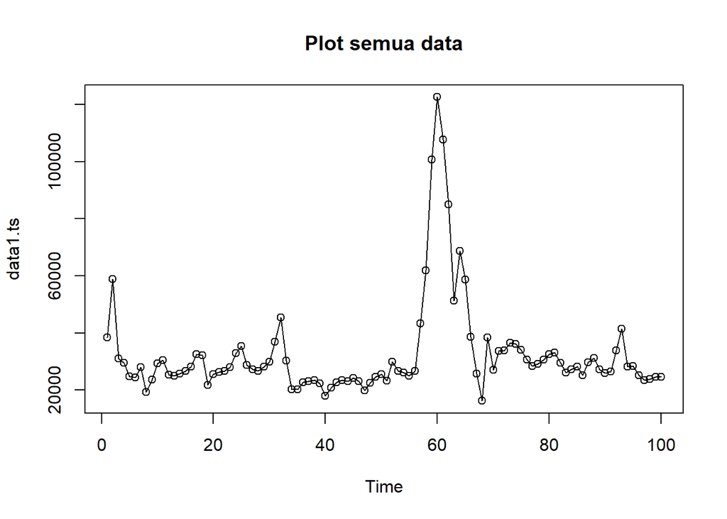

```r
#eksplorasi data keseluruhan data
plot(data1.ts, col="black",main="Plot semua data")
points(data1.ts)
```

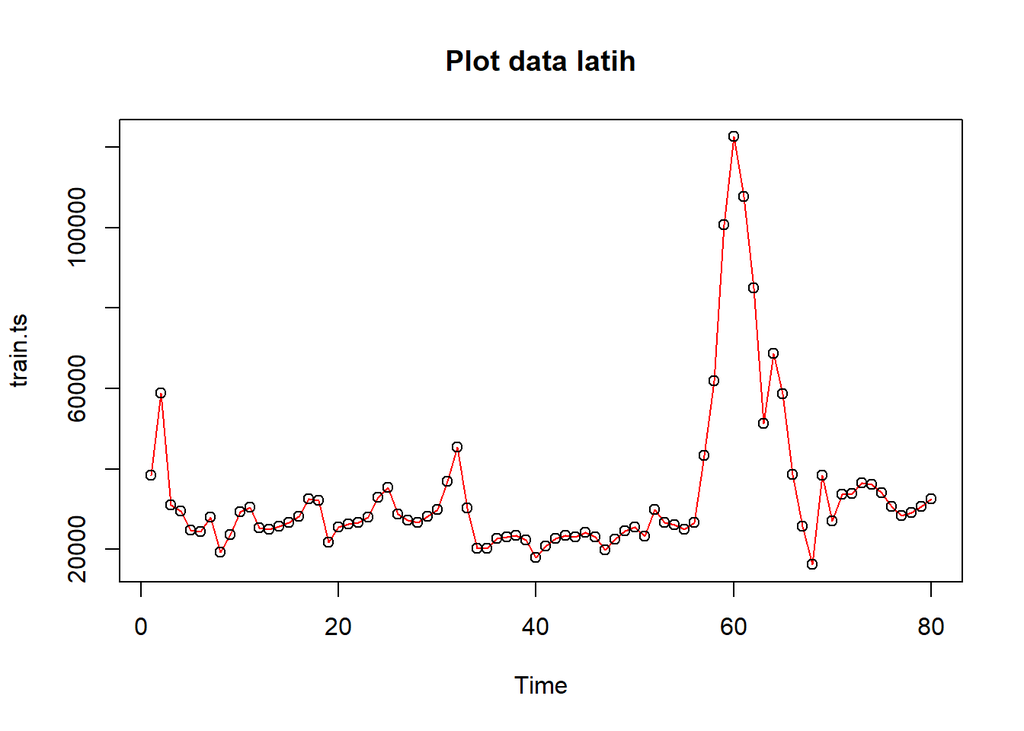

```r
#eksplorasi data latih
plot(train.ts, col="red",main="Plot data latih")
points(train.ts)
```

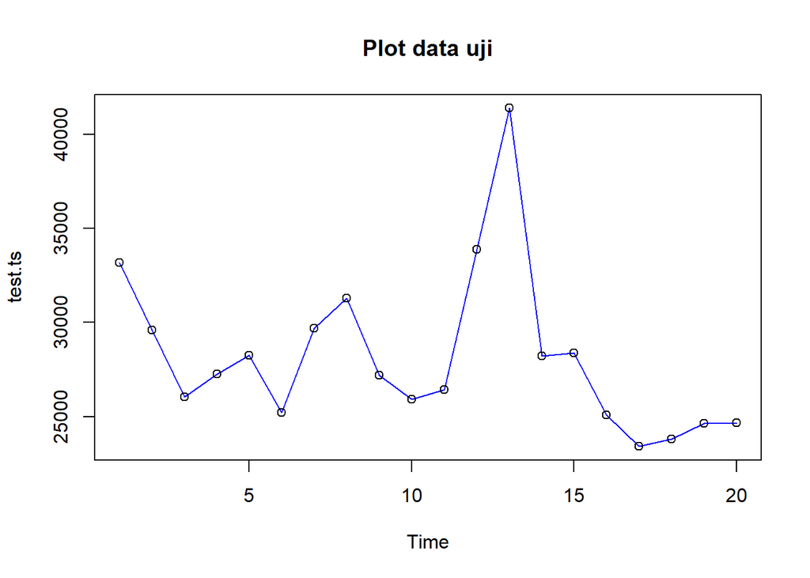

```r
#eksplorasi data uji
plot(test.ts, col="blue",main="Plot data uji")
points(test.ts)
```

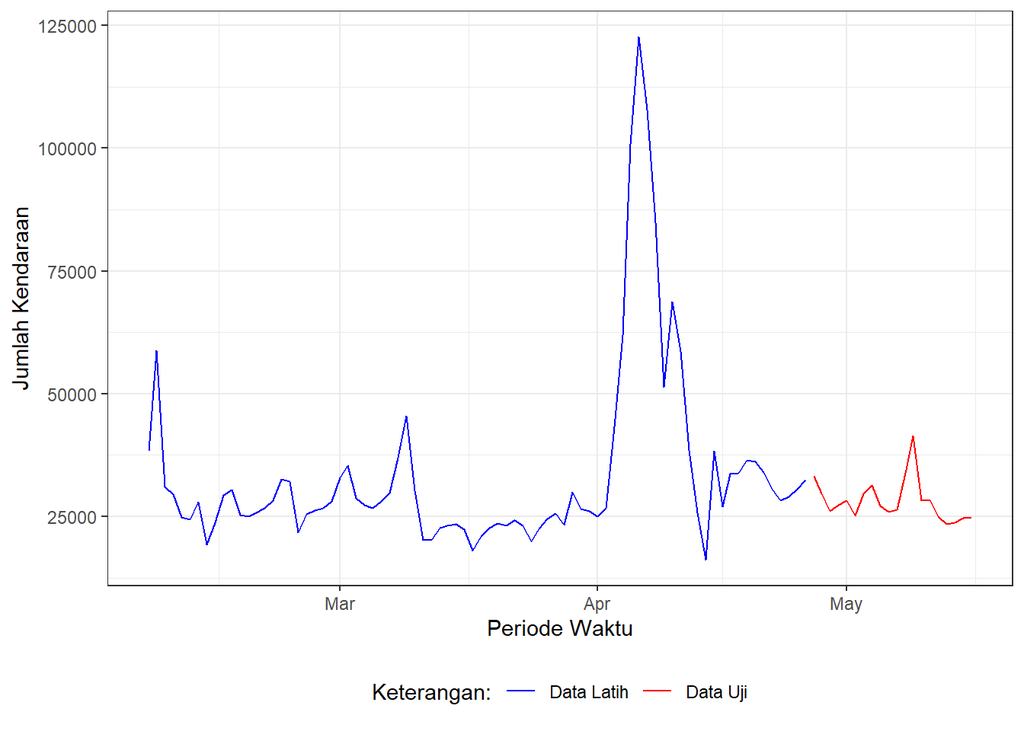

```r
#Eksplorasi dengan GGPLOT
library(ggplot2)
ggplot() +
  geom_line(data = training, aes(x = Periode, y = Kendaraan, col = "Data Latih")) +
  geom_line(data = testing, aes(x = Periode, y = Kendaraan, col = "Data Uji")) +
  labs(x = "Periode Waktu", y = "Jumlah Kendaraan", color = "Legend") +
  scale_colour_manual(name="Keterangan:", breaks = c("Data Latih", "Data Uji"),
                      values = c("blue", "red")) +
  theme_bw() + theme(legend.position = "bottom",
                     plot.caption = element_text(hjust=0.5, size=12))
```

### 1. SES (Single Exponential Smoothing)

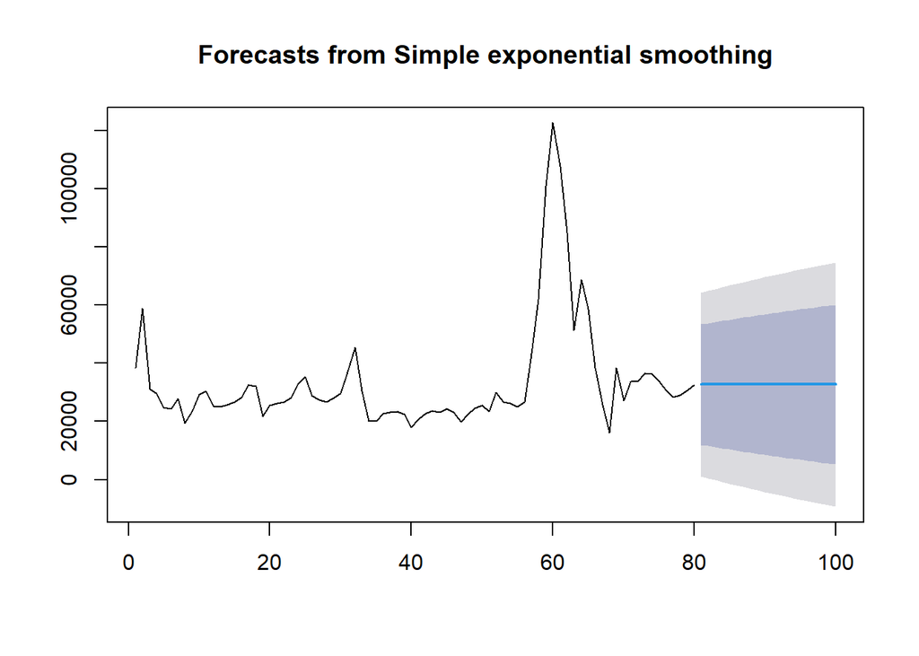

```r
library(forecast)
#Cara 1 (fungsi ses)
ses.1 <- ses(train.ts, h = 20, alpha = 0.2)
plot(ses.1)
```

```r
ses.1
```

```
##     Point Forecast     Lo 80    Hi 80      Lo 95    Hi 95
##  81       32673.03 11996.725 53349.34  1051.3486 64294.72
##  82       32673.03 11587.253 53758.81   425.1159 64920.95
##  83       32673.03 11185.583 54160.48  -189.1854 65535.25
##  84       32673.03 10791.285 54554.78  -792.2122 66138.28
##  85       32673.03 10403.968 54942.10 -1384.5634 66730.63
##  86       32673.03 10023.272 55322.79 -1966.7867 67312.85
##  87       32673.03  9648.871 55697.19 -2539.3844 67885.45
##  88       32673.03  9280.461 56065.60 -3102.8189 68448.88
##  89       32673.03  8917.764 56428.30 -3657.5163 69003.58
##  90       32673.03  8560.521 56785.54 -4203.8710 69549.94
##  91       32673.03  8208.495 57137.57 -4742.2485 70088.31
##  92       32673.03  7861.463 57484.60 -5272.9882 70619.05
##  93       32673.03  7519.219 57826.85 -5796.4063 71142.47
##  94       32673.03  7181.568 58164.50 -6312.7977 71658.86
##  95       32673.03  6848.332 58497.73 -6822.4381 72168.50
##  96       32673.03  6519.342 58826.72 -7325.5854 72671.65
##  97       32673.03  6194.439 59151.63 -7822.4817 73168.55
##  98       32673.03  5873.475 59472.59 -8313.3543 73659.42
##  99       32673.03  5556.309 59789.76 -8798.4172 74144.48
## 100       32673.03  5242.811 60103.25 -9277.8718 74623.94
```

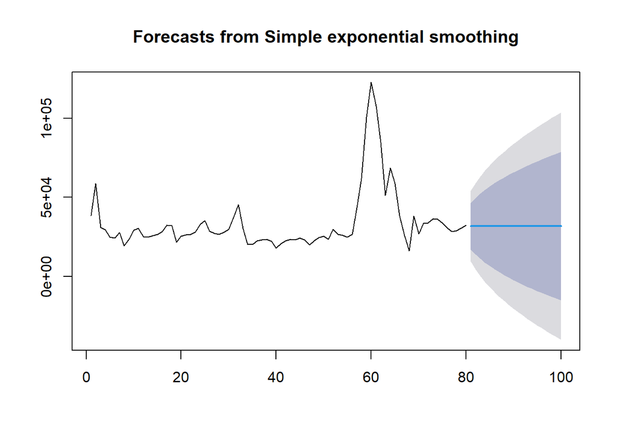

```r
ses.2<- ses(train.ts, h = 20, alpha = 0.7)
plot(ses.2)
```

```r
ses.2
```

```
##     Point Forecast       Lo 80    Hi 80       Lo 95     Hi 95
##  81       31782.23  17172.1932 46392.27   9438.1055  54126.36
##  82       31782.23  13948.4067 49616.06   4507.7496  59056.72
##  83       31782.23  11224.0849 52340.38    341.2588  63223.21
##  84       31782.23   8820.7533 54743.71  -3334.3197  66898.79
##  85       31782.23   6646.1703 56918.30  -6660.0573  70224.52
##  86       31782.23   4645.2888 58919.18  -9720.1416  73284.61
##  87       31782.23   2782.1324 60782.33 -12569.5934  76134.06
##  88       31782.23   1031.6569 62532.81 -15246.7147  78811.18
##  89       31782.23   -624.4025 64188.87 -17779.4390  81343.90
##  90       31782.23  -2199.8523 65764.32 -20188.8815  83753.35
##  91       31782.23  -3705.4299 67269.90 -22491.4637  86055.93
##  92       31782.23  -5149.6816 68714.15 -24700.2560  88264.72
##  93       31782.23  -6539.5416 70104.01 -26825.8635  90390.33
##  94       31782.23  -7880.7284 71445.19 -28877.0316  92441.50
##  95       31782.23  -9178.0233 72742.49 -30861.0731  94425.54
##  96       31782.23 -10435.4729 73999.94 -32784.1763  96348.64
##  97       31782.23 -11656.5376 75221.00 -34651.6335  98216.10
##  98       31782.23 -12844.2040 76408.67 -36468.0126 100032.48
##  99       31782.23 -14001.0716 77565.54 -38237.2889 101801.75
## 100       31782.23 -15129.4188 78693.88 -39962.9470 103527.41
```

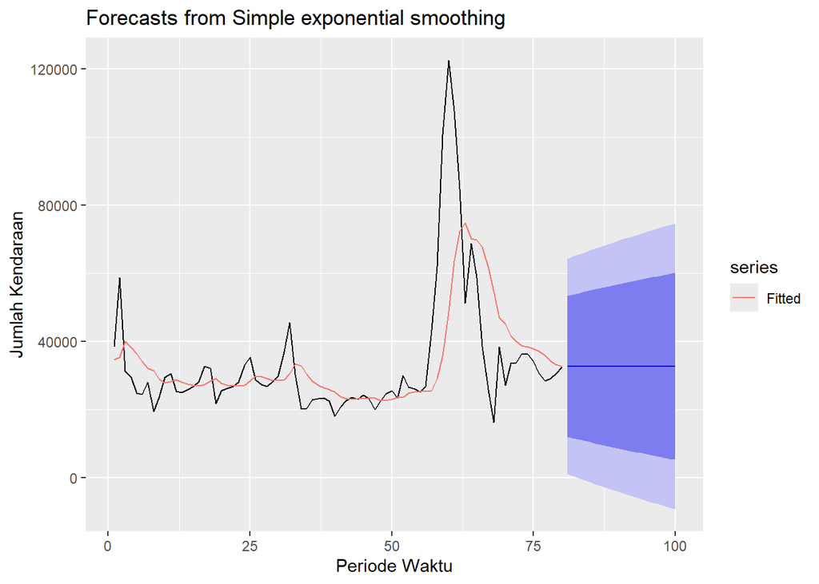

```r
# plot hasil pemulusan pada data latih dengan fungsi `ses()`
autoplot(ses.1) +
  autolayer(fitted(ses.1), series="Fitted") +
  ylab("Jumlah Kendaraan") + xlab("Periode Waktu")
```

- Nilai `y`: Nilai data deret waktu
- `gamma` : Parameter pemulusan untuk komponen musiman
- `beta` : Parameter pemulusan untuk tren
- `alpha` : Parameter pemulusan untuk stasioner
- `h` : Banyaknya periode yang akan diramalkan.

Kasus di atas merupakan contoh inisialisasi nilai parameter $\lambda$ dengan nilai `alpha` 0,2 dan 0,7 dan banyak periode data yang akan diramalkan adalah sebanyak 20 periode. Selanjutnya akan digunakan fungsi `HoltWinters()` dengan nilai inisialisasi parameter dan panjang periode peramalan yang sama dengan fungsi `ses()` .

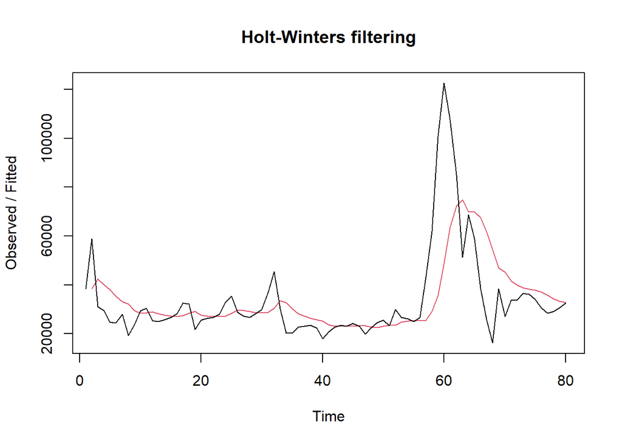

```r
#Cara 2 (fungsi Holtwinter)
ses1<- HoltWinters(train.ts, gamma = FALSE, beta = FALSE, alpha = 0.2)
plot(ses1)
```

```r
#ramalan
ramalan1<- forecast(ses1, h=20)
ramalan1
```

```
##     Point Forecast     Lo 80    Hi 80      Lo 95    Hi 95
##  81       32673.03 11980.936 53365.13  1027.2023 64318.86
##  82       32673.03 11571.152 53774.91   400.4913 64945.57
##  83       32673.03 11169.175 54176.89  -214.2790 65560.34
##  84       32673.03 10774.576 54571.49  -817.7662 66163.83
##  85       32673.03 10386.963 54959.10 -1410.5698 66756.64
##  86       32673.03 10005.977 55340.09 -1993.2377 67339.30
##  87       32673.03  9631.289 55714.78 -2566.2727 67912.34
##  88       32673.03  9262.598 56083.47 -3130.1374 68476.20
##  89       32673.03  8899.624 56446.44 -3685.2584 69031.32
##  90       32673.03  8542.109 56803.96 -4232.0303 69578.10
##  91       32673.03  8189.814 57156.25 -4770.8188 70116.88
##  92       32673.03  7842.517 57503.55 -5301.9638 70648.03
##  93       32673.03  7500.011 57846.05 -5825.7816 71171.85
##  94       32673.03  7162.103 58183.96 -6342.5673 71688.63
##  95       32673.03  6828.613 58517.45 -6852.5968 72198.66
##  96       32673.03  6499.371 58846.69 -7356.1283 72702.19
##  97       32673.03  6174.220 59171.85 -7853.4041 73199.47
##  98       32673.03  5853.011 59493.05 -8344.6515 73690.72
##  99       32673.03  5535.603 59810.46 -8830.0848 74176.15
## 100       32673.03  5221.865 60124.20 -9309.9056 74655.97
```

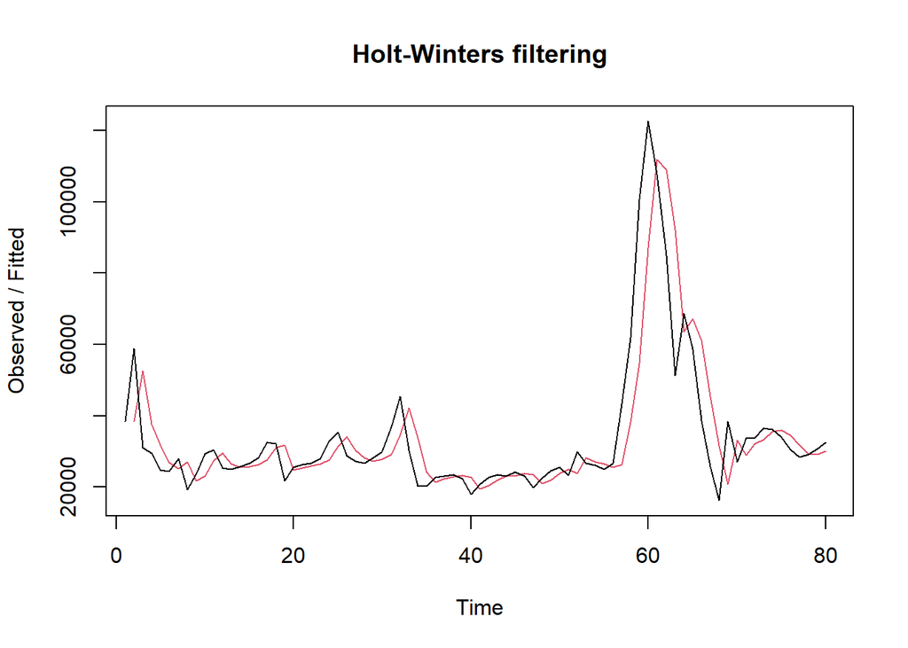

```r
ses2<- HoltWinters(train.ts, gamma = FALSE, beta = FALSE, alpha = 0.7)
plot(ses2)
```

```r
#ramalan
ramalan2<- forecast(ses2, h=20)
ramalan2
```

```
##     Point Forecast       Lo 80    Hi 80       Lo 95     Hi 95
##  81       31782.23  17163.0475 46401.42   9424.1184  54140.35
##  82       31782.23  13937.2430 49627.22   4490.6761  59073.79
##  83       31782.23  11211.2157 52353.25    321.5772  63242.89
##  84       31782.23   8806.3797 54758.09  -3356.3021  66920.77
##  85       31782.23   6630.4355 56934.03  -6684.1216  70248.59
##  86       31782.23   4628.3014 58936.16  -9746.1215  73310.59
##  87       31782.23   2763.9787 60800.49 -12597.3571  76161.82
##  88       31782.23   1012.4074 62552.06 -15276.1541  78840.62
##  89       31782.23   -644.6887 64209.15 -17810.4639  81374.93
##  90       31782.23  -2221.1246 65785.59 -20221.4147  83785.88
##  91       31782.23  -3727.6447 67292.11 -22525.4383  86089.90
##  92       31782.23  -5172.8004 68737.27 -24735.6133  88300.08
##  93       31782.23  -6563.5305 70128.00 -26862.5514  90427.02
##  94       31782.23  -7905.5568 71470.02 -28915.0035  92479.47
##  95       31782.23  -9203.6639 72768.13 -30900.2869  94464.75
##  96       31782.23 -10461.9006 74026.37 -32824.5940  96389.06
##  97       31782.23 -11683.7296 75248.20 -34693.2202  98257.69
##  98       31782.23 -12872.1396 76436.60 -36510.7364 100075.20
##  99       31782.23 -14029.7313 77594.20 -38281.1201 101845.59
## 100       31782.23 -15158.7848 78723.25 -40007.8585 103572.32
```

Fungsi `HoltWinters` memiliki argumen yang sama dengan fungsi `ses()` .

Nilai parameter $\alpha$ dari kedua fungsi dapat dioptimalkan menyesuaikan dari *error*-nya paling minimumnya. Caranya adalah dengan membuat parameter $\alpha =$ `NULL` .

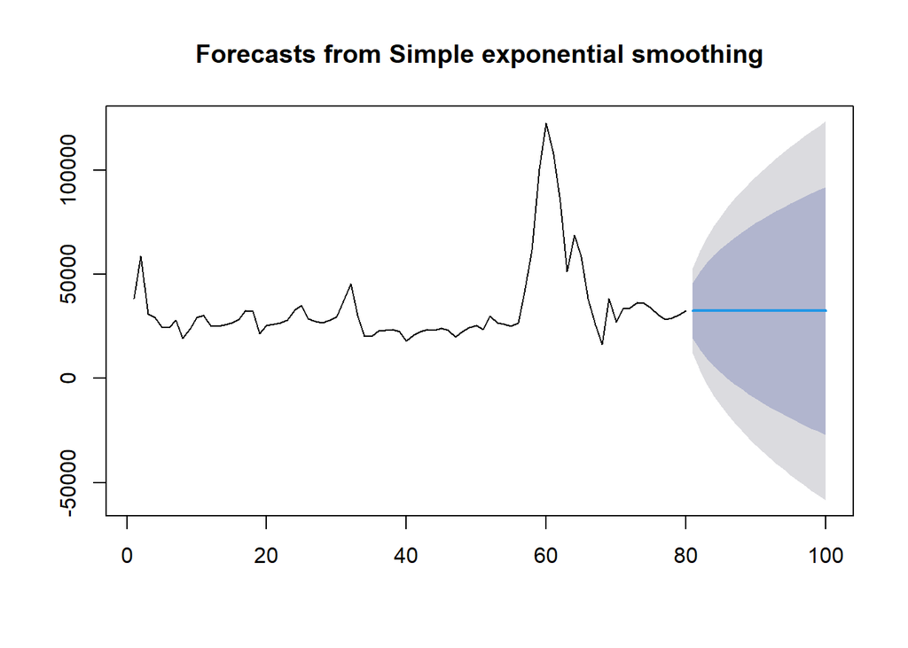

```r
#SES atau HoltWinters
ses.opt <- ses(train.ts, h = 20, alpha = NULL)
plot(ses.opt)
```

```r
ses.opt
```

```
##     Point Forecast       Lo 80    Hi 80      Lo 95     Hi 95
##  81       32485.81  19164.5728 45807.04  12112.737  52858.88
##  82       32485.81  13647.6785 51323.94   3675.375  61296.24
##  83       32485.81   9414.2902 55557.33  -2799.034  67770.65
##  84       32485.81   5845.3360 59126.28  -8257.278  73228.89
##  85       32485.81   2701.0038 62270.61 -13066.119  78037.74
##  86       32485.81   -141.7015 65113.32 -17413.662  82385.28
##  87       32485.81  -2755.8462 67727.46 -21411.651  86383.27
##  88       32485.81  -5189.0377 70160.65 -25132.896  90104.51
##  89       32485.81  -7474.3448 72445.96 -28627.972  93599.59
##  90       32485.81  -9635.8447 74607.46 -31933.701  96905.32
##  91       32485.81 -11691.7139 76663.33 -35077.881 100049.50
##  92       32485.81 -13656.0738 78627.69 -38082.111 103053.73
##  93       32485.81 -15540.1544 80511.77 -40963.563 105935.18
##  94       32485.81 -17353.0612 82324.68 -43736.165 108707.78
##  95       32485.81 -19102.2981 84073.91 -46411.392 111383.01
##  96       32485.81 -20794.1367 85765.75 -48998.836 113970.45
##  97       32485.81 -22433.8817 87405.50 -51506.609 116478.23
##  98       32485.81 -24026.0680 88997.68 -53941.648 118913.26
##  99       32485.81 -25574.6083 90546.22 -56309.936 121281.55
## 100       32485.81 -27082.9066 92054.52 -58616.679 123588.30
```

```r
#Lamda Optimum Holt Winter
sesopt<- HoltWinters(train.ts, gamma = FALSE, beta = FALSE,alpha = NULL)
sesopt
```

```
## Holt-Winters exponential smoothing without trend and without seasonal component.
##
## Call:
## HoltWinters(x = train.ts, alpha = NULL, beta = FALSE, gamma = FALSE)
##
## Smoothing parameters:
##  alpha: 0.9999341
##  beta : FALSE
##  gamma: FALSE
##
## Coefficients:
##       [,1]
## a 32485.87
```

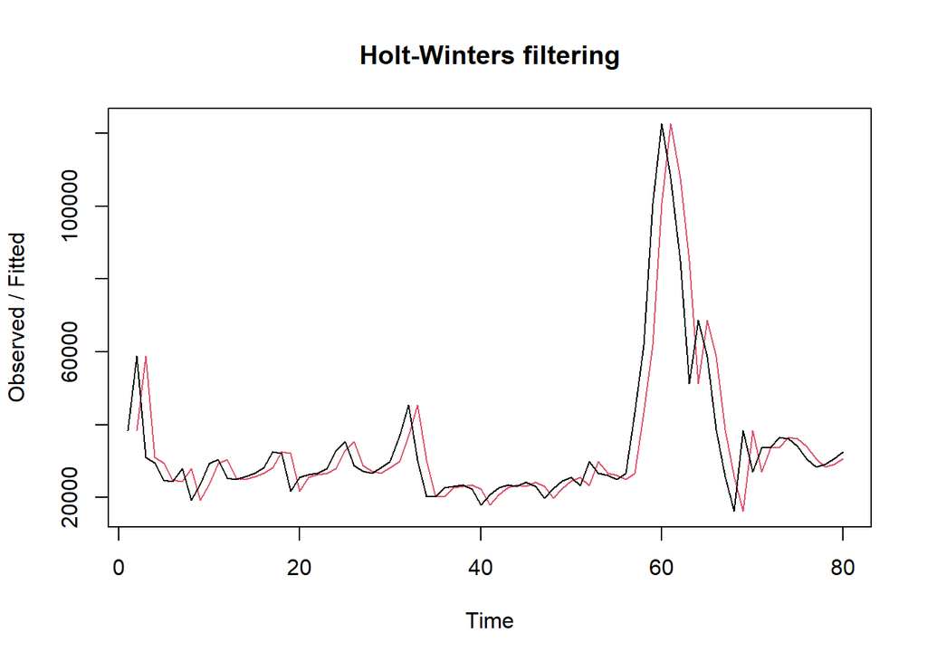

```r
plot(sesopt)
```

```r
#ramalan
ramalanopt<- forecast(sesopt, h=20)
ramalanopt
```

```
##     Point Forecast       Lo 80    Hi 80      Lo 95     Hi 95
##  81       32485.87  19165.0671 45806.68  12113.458  52858.29
##  82       32485.87  13648.0295 51323.72   3675.877  61295.87
##  83       32485.87   9414.5742 55557.17  -2798.634  67770.38
##  84       32485.87   5845.5781 59126.17  -8256.942  73228.69
##  85       32485.87   2701.2160 62270.53 -13065.829  78037.58
##  86       32485.87   -141.5123 65113.26 -17413.407  82385.15
##  87       32485.87  -2755.6757 67727.42 -21411.425  86383.17
##  88       32485.87  -5188.8830 70160.63 -25132.694  90104.44
##  89       32485.87  -7474.2036 72445.95 -28627.791  93599.54
##  90       32485.87  -9635.7153 74607.46 -31933.537  96905.28
##  91       32485.87 -11691.5951 76663.34 -35077.734 100049.48
##  92       32485.87 -13655.9645 78627.71 -38081.978 103053.72
##  93       32485.87 -15540.0538 80511.80 -40963.444 105935.19
##  94       32485.87 -17352.9686 82324.72 -43736.058 108707.80
##  95       32485.87 -19102.2130 84073.96 -46411.296 111383.04
##  96       32485.87 -20794.0585 85765.81 -48998.751 113970.50
##  97       32485.87 -22433.8100 87405.56 -51506.534 116478.28
##  98       32485.87 -24026.0024 88997.75 -53941.582 118913.33
##  99       32485.87 -25574.5485 90546.30 -56309.879 121281.63
## 100       32485.87 -27082.8522 92054.60 -58616.631 123588.38
```

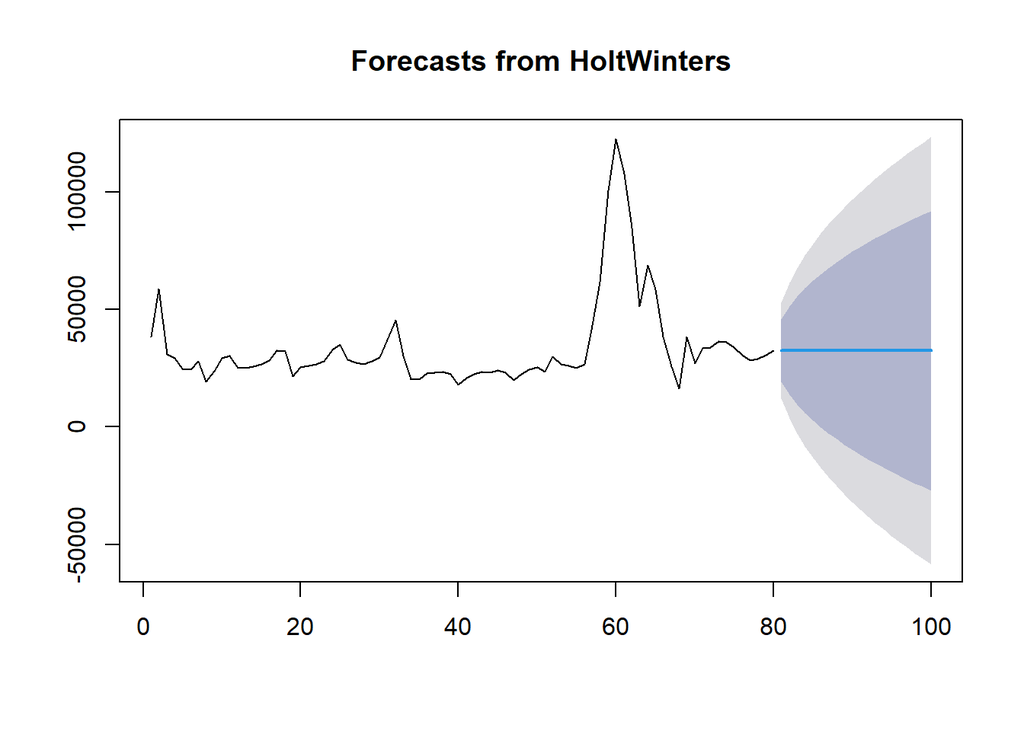

```r
plot(ramalanopt)
```

#### Akurasi Data Latih

Perhitungan akurasi data dapat dilakukan dengan cara langsung maupun manual. Secara langsung, nilai akurasi dapat diambil dari objek yang tersimpan pada hasil SES, yaitu *sum of squared errors* (SSE). Nilai akurasi lain dapat dihitung pula dari nilai SSE tersebut.

```r
#Keakuratan Metode
#Pada data training
SSE1<-ses1$SSE
MSE1<-ses1$SSE/length(train.ts)
RMSE1<-sqrt(MSE1)

akurasi1 <- matrix(c(SSE1,MSE1,RMSE1))
row.names(akurasi1)<- c("SSE", "MSE", "RMSE")
colnames(akurasi1) <- c("Akurasi lamda=0.2")
akurasi1
```

```
##      Akurasi lamda=0.2
## SSE       2.034475e+10
## MSE       2.543093e+08
## RMSE      1.594708e+04
```

```r
SSE2<-ses2$SSE
MSE2<-ses2$SSE/length(train.ts)
RMSE2<-sqrt(MSE2)

akurasi2 <- matrix(c(SSE2,MSE2,RMSE2))
row.names(akurasi2)<- c("SSE", "MSE", "RMSE")
colnames(akurasi2) <- c("Akurasi lamda=0.7")
akurasi2
```

```
##      Akurasi lamda=0.7
## SSE       1.015119e+10
## MSE       1.268899e+08
## RMSE      1.126454e+04
```

```r
#Cara Manual
fitted1<-ramalan1$fitted
sisaan1<-ramalan1$residuals
head(sisaan1)
```

```
## Time Series:
## Start = 1
## End = 6
## Frequency = 1
## [1]        NA  20400.00 -11349.00 -10756.20 -13271.96 -11024.57
```

```r
resid1<-training$Kendaraan-ramalan1$fitted
head(resid1)
```

```
## Time Series:
## Start = 1
## End = 6
## Frequency = 1
## [1]        NA  20400.00 -11349.00 -10756.20 -13271.96 -11024.57
```

```r
#Cara Manual
SSE.1=sum(sisaan1[2:length(train.ts)]^2)
SSE.1
```

```
## [1] 20344745393
```

```r
MSE.1 = SSE.1/length(train.ts)
MSE.1
```

```
## [1] 254309317
```

```r
MAPE.1 = sum(abs(sisaan1[2:length(train.ts)]/train.ts[2:length(train.ts)])*
               100)/length(train.ts)
MAPE.1
```

```
## [1] 23.96857
```

```r
akurasi.1 <- matrix(c(SSE.1,MSE.1,MAPE.1))
row.names(akurasi.1)<- c("SSE", "MSE", "MAPE")
colnames(akurasi.1) <- c("Akurasi lamda=0.2")
akurasi.1
```

```
##      Akurasi lamda=0.2
## SSE       2.034475e+10
## MSE       2.543093e+08
## MAPE      2.396857e+01
```

```r
fitted2<-ramalan2$fitted
sisaan2<-ramalan2$residuals
head(sisaan2)
```

```
## Time Series:
## Start = 1
## End = 6
## Frequency = 1
## [1]         NA  20400.000 -21549.000  -8141.700  -7109.510  -2539.853
```

```r
resid2<-training$Kendaraan-ramalan2$fitted
head(resid2)
```

```
## Time Series:
## Start = 1
## End = 6
## Frequency = 1
## [1]         NA  20400.000 -21549.000  -8141.700  -7109.510  -2539.853
```

```r
SSE.2=sum(sisaan2[2:length(train.ts)]^2)
SSE.2
```

```
## [1] 10151191579
```

```r
MSE.2 = SSE.2/length(train.ts)
MSE.2
```

```
## [1] 126889895
```

```r
MAPE.2 = sum(abs(sisaan2[2:length(train.ts)]/train.ts[2:length(train.ts)])*
               100)/length(train.ts)
MAPE.2
```

```
## [1] 17.98001
```

```r
akurasi.2 <- matrix(c(SSE.2,MSE.2,MAPE.2))
row.names(akurasi.2)<- c("SSE", "MSE", "MAPE")
colnames(akurasi.2) <- c("Akurasi lamda=0.7")
akurasi.2
```

```
##      Akurasi lamda=0.7
## SSE       1.015119e+10
## MSE       1.268899e+08
## MAPE      1.798001e+01
```

#### Akurasi Data Uji

```r
selisih1<-ramalan1$mean-testing$Kendaraan
SSEtesting1<-sum(selisih1^2)
MSEtesting1<-SSEtesting1/length(testing)

selisih2<-ramalan2$mean-testing$Kendaraan
SSEtesting2<-sum(selisih2^2)
MSEtesting2<-SSEtesting2/length(testing)

selisihopt<-ramalanopt$mean-testing$Kendaraan
SSEtestingopt<-sum(selisihopt^2)
MSEtestingopt<-SSEtestingopt/length(testing)

akurasitesting1 <- matrix(c(SSEtesting1,SSEtesting2,SSEtestingopt))
row.names(akurasitesting1)<- c("SSE1", "SSE2", "SSEopt")
akurasitesting1
```

```
##             [,1]
## SSE1   750623190
## SSE2   606210867
## SSEopt 717647941
```

```r
akurasitesting2 <- matrix(c(MSEtesting1,MSEtesting2,MSEtestingopt))
row.names(akurasitesting2)<- c("MSE1", "MSE2", "MSEopt")
akurasitesting2
```

```
##             [,1]
## MSE1   375311595
## MSE2   303105434
## MSEopt 358823970
```

```r
#cara lain
accuracy(ramalanopt,testing$Kendaraan)
```

```
##                       ME      RMSE      MAE        MPE     MAPE      MASE
## Training set   -74.74071 10328.555 6350.467  -3.036193 17.04741 1.0000097
## Test set     -4311.12341  5990.192 5408.361 -17.442096 20.20824 0.8516561
##                   ACF1
## Training set 0.1761829
## Test set            NA
```

### 2. DES (Double Exponential Smoothing)

- Digunakan untuk data yang memiliki pola tren
- Metode semacam SES, hanya saja dilakukan dua kali(pertama untuk tahapan ‘level’ dan kedua untuk tahapan ‘tren’)
- Akan menghasilkan peramalan tidak konstan untuk periode berikutnya.
- Pemulusan dengan metode DES kali ini akan menggunakan fungsi `HoltWinters()` . Jika sebelumnya nilai argumen `beta` dibuat `FALSE` , kali ini argumen tersebut akan diinisialisasi bersamaan dengan nilai `alpha` .

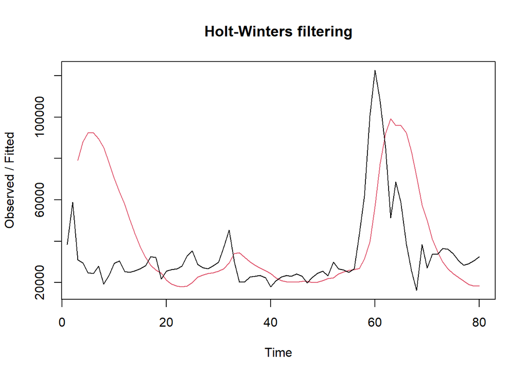

```r
#Lamda=0.2 dan gamma=0.2
des.1<- HoltWinters(train.ts, gamma = FALSE, beta = 0.2, alpha = 0.2)
plot(des.1)
```

```r
#ramalan
ramalandes1<- forecast(des.1, h=20)
ramalandes1
```

```
##     Point Forecast      Lo 80    Hi 80      Lo 95     Hi 95
##  81     19647.2825  -14464.23 53758.79  -32521.77  71816.33
##  82     17955.4158  -17124.75 53035.58  -35695.07  71605.90
##  83     16263.5492  -20093.62 52620.72  -39339.95  71867.05
##  84     14571.6825  -23388.77 52532.14  -43483.82  72627.19
##  85     12879.8159  -27017.53 52777.16  -48137.91  73897.54
##  86     11187.9492  -30978.07 53353.97  -53299.41  75675.31
##  87      9496.0826  -35261.55 54253.71  -58954.80  77946.97
##  88      7804.2159  -39854.34 55462.77  -65083.25  80691.68
##  89      6112.3493  -44740.12 56964.82  -71659.79  83884.49
##  90      4420.4826  -49901.49 58742.46  -78657.81  87498.78
##  91      2728.6160  -55321.12 60778.35  -86050.79  91508.02
##  92      1036.7493  -60982.44 63055.94  -93813.42  95886.92
##  93      -655.1173  -66870.12 65559.88 -101922.22 100611.99
##  94     -2346.9840  -72970.17 68276.20 -110355.82 105661.85
##  95     -4038.8506  -79270.00 71192.30 -119094.97 111017.27
##  96     -5730.7173  -85758.38 74296.95 -128122.47 116661.04
##  97     -7422.5839  -92425.29 77580.12 -137423.00 122577.84
##  98     -9114.4506  -99261.82 81032.92 -146982.95 128754.05
##  99    -10806.3172 -106260.05 84647.42 -156790.20 135177.57
## 100    -12498.1839 -113412.92 88416.55 -166833.96 141837.59
```

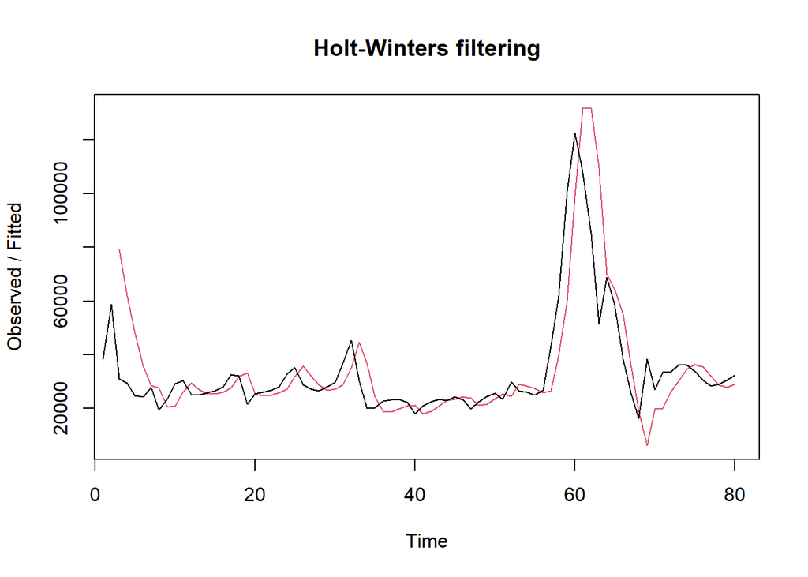

```r
#Lamda=0.6 dan gamma=0.3
des.2<- HoltWinters(train.ts, gamma = FALSE, beta = 0.3, alpha = 0.6)
plot(des.2)
```

```r
#ramalan
ramalandes2<- forecast(des.2, h=20)
ramalandes2
```

```
##     Point Forecast       Lo 80     Hi 80       Lo 95     Hi 95
##  81       31141.53   12525.039  49758.01    2670.065  59612.99
##  82       31218.24    7608.306  54828.18   -4890.038  67326.52
##  83       31294.96    1683.619  60906.29  -13991.676  76581.59
##  84       31371.67   -5059.612  67802.95  -24345.168  87088.51
##  85       31448.38  -12495.992  75392.76  -35758.740  98655.51
##  86       31525.10  -20541.194  83591.39  -48103.425 111153.62
##  87       31601.81  -29135.887  92339.51  -61288.484 124492.11
##  88       31678.53  -38236.237 101593.29  -75246.878 138603.94
##  89       31755.24  -47808.412 111318.90  -89926.867 153437.35
##  90       31831.96  -57825.327 121489.24 -105287.027 168950.94
##  91       31908.67  -68264.641 132081.99 -121293.191 185110.53
##  92       31985.39  -79107.482 143078.26 -137916.494 201887.27
##  93       32062.10  -90337.591 154461.79 -155132.074 219256.28
##  94       32138.82 -101940.745 166218.38 -172918.176 237195.81
##  95       32215.53 -113904.334 178335.39 -191255.518 255686.58
##  96       32292.24 -126217.066 190801.56 -210126.826 274711.32
##  97       32368.96 -138868.732 203606.65 -229516.490 294254.41
##  98       32445.67 -151850.035 216741.38 -249410.291 314301.64
##  99       32522.39 -165152.457 230197.23 -269795.199 334839.98
## 100       32599.10 -178768.144 243966.35 -290659.205 355857.41
```

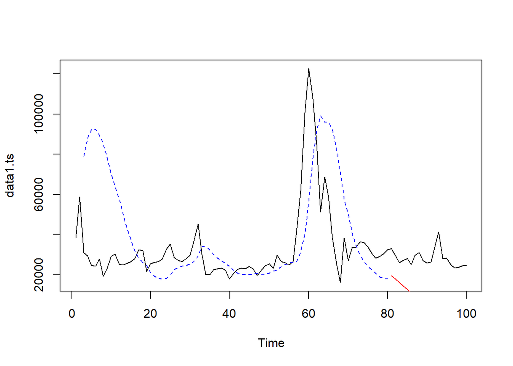

```r
#Perbandingkan plot data latih dan data uji
plot(data1.ts)
lines(des.1$fitted[,1], lty=2, col="blue")
lines(ramalandes1$mean, col="red")
```

```r
#Lamda dan gamma optimum
des.opt<- HoltWinters(train.ts, gamma = FALSE)
des.opt
```

```
## Holt-Winters exponential smoothing with trend and without seasonal component.
##
## Call:
## HoltWinters(x = train.ts, gamma = FALSE)
##
## Smoothing parameters:
##  alpha: 1
##  beta : 0.2809511
##  gamma: FALSE
##
## Coefficients:
##         [,1]
## a 32486.0000
## b   362.9826
```

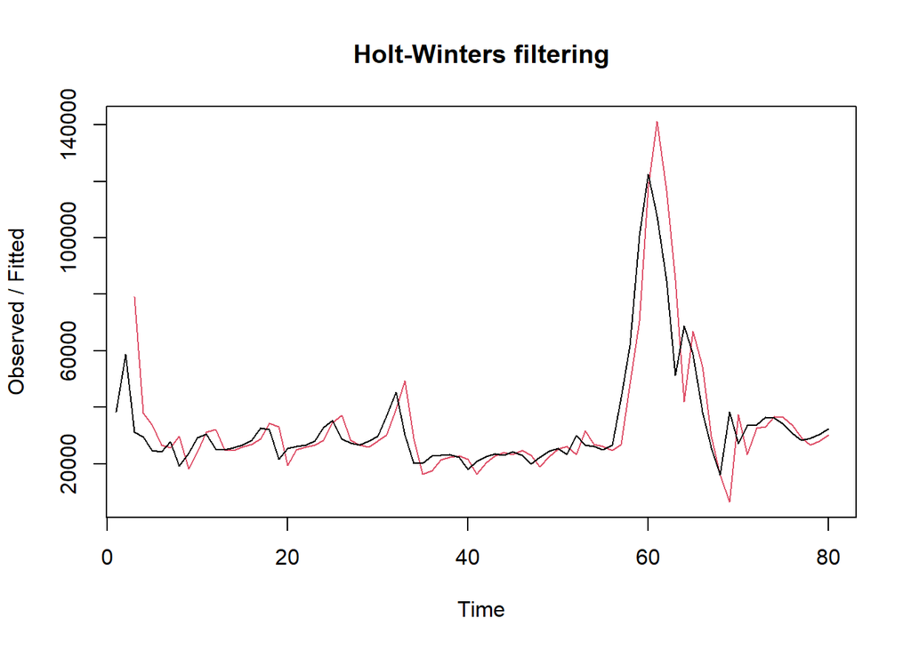

```r
plot(des.opt)
```

```r
#ramalan
ramalandesopt<- forecast(des.opt, h=20)
ramalandesopt
```

```
##     Point Forecast        Lo 80     Hi 80       Lo 95     Hi 95
##  81       32848.98   17780.0039  47917.96    9802.968  55895.00
##  82       33211.97    8723.8982  57700.03   -4239.301  70663.23
##  83       33574.95    -390.0551  67539.95  -18370.041  85519.94
##  84       33937.93   -9934.4940  77810.35  -33159.152 101035.01
##  85       34300.91  -20003.9443  88605.77  -48751.199 117353.02
##  86       34663.90  -30621.2686  99949.06  -65181.147 134508.94
##  87       35026.88  -41784.8561 111838.61  -82446.532 152500.29
##  88       35389.86  -53483.8396 124263.56 -100530.734 171310.46
##  89       35752.84  -65703.9280 137209.61 -119411.898 190917.58
##  90       36115.83  -78429.8660 150661.52 -139066.692 211298.34
##  91       36478.81  -91646.5185 164604.13 -159471.969 232429.59
##  92       36841.79 -105339.3453 179022.93 -180605.492 254289.07
##  93       37204.77 -119494.5928 193904.14 -202446.226 276855.77
##  94       37567.76 -134099.3479 209234.86 -224974.423 300109.93
##  95       37930.74 -149141.5271 225003.00 -248171.602 324033.08
##  96       38293.72 -164609.8345 241197.28 -272020.488 348607.93
##  97       38656.70 -180493.7081 257807.11 -296504.928 373818.33
##  98       39019.69 -196783.2620 274822.63 -321609.802 399649.17
##  99       39382.67 -213469.2299 292234.57 -347320.940 426086.28
## 100       39745.65 -230542.9117 310034.21 -373625.034 453116.34
```